# Risk Factors and Treatment of Refractory Anaphylaxis - a systematic review

Wojciech Francuzik

Margitta Worm, MD

20 November, 2017

Abstract

Department of Dermatology, Venerology and Allergology, Charité – Universitätsmedizin Berlin, corporate member of Freie Universität Berlin, Humboldt-Universität zu Berlin, and Berlin Institute of Health, Charitéplatz 1, 10117 Berlin,

**Corresponding author:** Prof. Dr. med. M. Worm margitta.worm@charite.de Phone: +49 30 450 529 005; Fax: +49 30 450 529 902

# 1 Introduction:

**Incorporating basic background information on the area under review.**

## 1.1 Definitions

Anaphylaxis is a life-threathening immunologic reaction to an allergen (most frequently food, drugs, insect venom) that is hardly avoidable in clinical practice of various medical specialties.

Anaphylaxis is considered a clinical diagnosis and it is highly likely if there is an acute onset of skin symptoms with either hypotension or repiratory compromise, or when the allergen is known or likely (Sampson et al., 2006). Its pathogenesis relies on a sudden, systemic, (mostly IgE dependent) degranulation of mast cells or basophils.

The definition of *refractory* anaphylaxis is not established. For the purpose of this review we will define it as anaphylaxis (meeting the criteria by NIAID/FAAN (Sampson et al., 2006)) unresponsive to the treatment with at least 2 doses of minimum 300 µg adrenalin. Unresponsiveness in this case is defined as a lack of expected normalization of clinical symptoms after injection of adrenailn (i.e. rapid increase in blood pressure, bronchodilatation, tachycardia).

## 1.2 Epidemiology

The incidence of anaphylaxis is increasing worldwide (Koplin et al., 2011) and was lately estimated to be between 50 and 112 episodes per 100,000 person-years and an estimated prevalence of 0.3% to 5.1% (Tejedor Alonso et al., 2015). Anaphylaxis in children is usally food dependent and less severe than episodes in adulthood. Cases of refractory anaphylaxis are extremely rare. The incidence of refractory anaphylaxis was not investigated earlier and it is estimated (based on our experience) to be 3-5% of all cases of anaphylaxis.

## 1.4 Managment

The managment algorithms for anaphylaxis are based on consensus expert recommendations and might be incomplete when it comes to reactions that are not responding to the first line therapy.  
Research in anaphylaxis treatment is difficult because it is an emergency condition. Therefore most of the knowledge is based on expert recommendations which are graded as low-level evidence sources.

We aimed to reevaluate the management and risk factors of refractory anaphylaxis to highlight possible clinical implications for updating current managment algorithms.

## 1.5 Literature search strategy

We have performed a database search in the “pubmed” database using the “RISmed”(Kovalchik, 2017) package for R statistical software (R Core Team, 2017). The search terms contained the words “refractory anaphylaxis” in articles published from 1950 till 2017. The search was conducted on 16.11.2017 and returned 150 results. Published case reports of anaphylaxis treated with repeated doses of epinephrine were included into the study (articles in English, Poltugese, French and Spanish were included into the analysis, one article in japanese was excluded). Additionally, case reports referenced in the included sources were added. We excluded reviews and papers not containg case description as well as cases which documented an appropriate response to injected adrenalin. Also cases describing Mast cell activation syndrome and refractory vasoplegia without the definitive diagnosis of anaphylaxis were not included. The detailed inclusion flowchart is illustrated in Fig 12.1.

We collected information about the elicitors, clinical setting, concomitant diseases, medication, reaction symptoms, therapy and outcomes of the treatment. We used piloted plots to gather the data and all reports were screened once by the same researcher.

All of the studies were case reports therfore the evidence level was classified as low.

The review protocol was not established prior to the review and the review did not undergo preregistration.

We have performed literature research identifying case reports of refractory anaphylaxis. All case reports of patients who experienced an anaphylactic event and did not respond to at least 600 µg of adrenalin were included into this study. We investigated which interventions were reported as succesfull in the treatment of anaphylactic hypotension that was not reponding to injected (i.v. or i.m) adrenailn. Study outcomes were defined as time to elicit a response and mortality. Most of these reports described refractory anaphylaxis in a perioperative setting, but they also included cases of food and drug anaphylaxis. Suprisingly, no cases of insect venom anphylaxis were found among these reports.

Outcomes: successful and unsuccesful managment of anaphylaxis was one of the most important outcomes we evaluated. This information was availible in all cases. Neurological deficits directly after the episode were also evaluated, but this measure might be biased.

# 2 Risk factors of refractory anaphylaxis

## 2.1 Clinical symptoms of refractory anaphylaxis

1. persistent hypotension - give methylene blue
2. betablockers prevent dequate response to adrenaline - give glucagon

# 3 Therapy of refractory anaphylaxis

# 4 Methylene blue for the treatment of refractory hypotension

# 5 Vasopressin as a supplementary vasopressor

# 6 Glucagon in anaphylaxis with concomitant beta blockers

# 7 Conclusion:

# 8 Expert Commentary: 500-1000 words (included in overall word count).

**To distinguish the articles published in the Expert Review series, authors must provide an additional section entitled ‘Expert Commentary’. This section affords authors the opportunity to provide their interpretation of the data presented in the article and discuss the developments that are likely to be important in the future, and the avenues of research likely to become exciting as further studies yield more detailed results. The intention is to go beyond a conclusion and should not simply summarise the paper. Authors should answer the following:**

## 8.1 What are the key weaknesses in clinical management so far?

## 8.2 What potential does further research hold? What is the ultimate goal in this field?

## 8.3 What research or knowledge is needed to achieve this goal and what is the biggest challenge in this goal being achieved?

## 8.4 Is there any particular area of the research you are finding of interest at present?

**Please note that ‘opinions’ are encouraged in the Expert commentary section, and, as such, referees are asked to keep this in mind when peer reviewing the manuscript.**

# 9 Five-year view

# 10 Key issues

**An executive summary of the authors’ main points (bulleted) is very useful for time-constrained readers requiring a rapidly accessible overview.**

# 11 References

**A maximum of 100 references is suggested. Ensure that all key work relevant to the topic under discussion is cited in the text and listed in the bibliography. Reference to unpublished data should be kept to a minimum and authors must obtain a signed letter of permission from cited persons to use unpublished results or personal communications in the manuscript.**

## 11.1 Annotated bibliography:

**Important references should be highlighted with a one/two star system and brief annotations should be given (see the journal’s Instructions for Authors page for examples and for a more detailed description of our referencing style).**

# 12 Figures and Tables:

**Up to 5 figures and 5 tables are permitted. For further information on tables and figures, please see our formatting guide**.

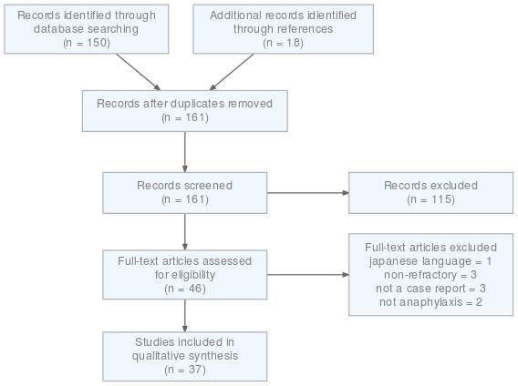

Figure 12.1: The PRISMA flowchart for included sources

–==SOURCE SENTENCES==– asthma poses higher risk of anaphylaxis (Koplin et al., 2011) less sun year-round is bound to higher food-induced anaphylaxis prevalence??? (Koplin et al., 2011) low Vitamin D levels are might be associated with anaphylaxis? (Koplin et al., 2011)

The mainstay of therapy is early administration of intramuscular (IM) adrenalin with addi- tional therapies including intravenous (IV) fluids, steroids, and an- tihistamines after the administration of adrenalin (Lazar et al., 2017).

external gastric drainage should be considered an integral part of the treatment of severe life-threatening food-induced anaphylaxis??? (Lazar et al., 2017)

CASES: 1. Male, 15yo, known milk allergy, food ANA, SPT +++, IgE+, Soy milk which previously contained cows milk. Epi 0.3 mg IM, repeated EPI + 0.6 mg, Salbutamol 5 mg intratracheal. 500 ml iv NaCl. 125 methylpred, Adrenalin 5mg/500 mL NACL - 10 µg/min. another Adreanlin 0.5 mg. ICU, Gastric lavage!!! 152 min after the exposure -> remission in 8 min. (Lazar et al., 2017)

The most important treatment of anaphylaxis includes early administration of IM adrenalin by an automatic injector1,2 (Lazar et al., 2017)

The patient’s condition began to improve shortly after placement of a nasogastric tube and gastric drainage, suggesting that milkwas still being absorbed fromthe gastricmu- cosa and contributing to the anaphylaxis even after the correct therapywas given. (Lazar et al., 2017)

Similarly, although not previously reported, many allergists be- lieve that vomiting after food-induced IgE-mediated allergic reac- tion seems to end the allergic reaction. (Lazar et al., 2017)

Protocols for therapy of anaphylaxis have been sug- gested1,2,4,5; however, none of these protocols include gastric drainage through a nasogastric tube as ameasure to decrease aller- gic absorption from the gastrointestinal tract in cases of severe anaphylaxis due to food. (Lazar et al., 2017)

Our case also shows the importance of early ventilation with supplemental 100%oxygen in severe, near-fatal anaphylaxis. (Lazar et al., 2017)

The most common causes of anaphylaxis are food and medications; however, Hymenoptera stings, radiocontrast media (RCM), and iatrogenic procedures SIT, (Coop et al., 2017)

Patients taking anti- hypertensive medications, specifically angiotensin converting enzyme (ACE) inhibitors or beta-blockers, represent a popula- tion in whom a possibly increased risk for anaphylaxis has been debated.3 (Coop et al., 2017)

Although the lifetime prevalence of anaphylaxis in the general population is estimated to be approximately 7% and possibly up to 10% to 12%, (Coop et al., 2017)

the prevalence of anaphylaxis in patients taking ACE inhibitors and beta-blockers is unknown.4 (Coop et al., 2017)

Anaphylaxis is classically initiated by allergen cross-linking of IgE on mast cells and basophils, leading to degranulation and release of histamine, tryptase, chymase, platelet-activating factor, prostaglandins, and leukotrienes.5,6 (Coop et al., 2017)

Release of these mediators activates inflammatory pathways, including the complement and kallikrein-kinin systems and the clotting cascade. Histamine release, in particular, causes vasodilation leading to increased vascular permeability and decreased peripheral vascular resis- tance.2 (Coop et al., 2017)

Decreased peripheral vascular resistance leads to activa- tion of the renin-angiotensin system, a compensatory mechanism blocked by ACE inhibitors, thus theoretically leading to inten- sified anaphylaxis. (Coop et al., 2017)

Histamine release also increases cardiac rate, cardiac contractility, and bronchoconstriction.2,5 Therefore, it is suggested that beta-blockers mask cardiac signs of anaphylaxis and lead to unopposed alpha-adrenergic activity, causing severe bronchoconstriction. (Coop et al., 2017)

Furthermore, management of anaphylaxis with concomitant beta-blocker use is complicated by the possi- bility of a blunted response to epinephrine and/or inhaled bronchodilators.7 (Coop et al., 2017)

Also animal studies suggest that ACE in- hibitors and beta-blockers together may enhance mast cell priming.8 (Coop et al., 2017)

Nitric oxide also plays a role in anaphylaxis. Nitric oxide can inhibit the release and effects of catecholamines. It causes vaso- dilation by increasing the activation of guanylyl cyclase that can result in smooth muscle relaxation via cyclic guanosine mono- phosphate.9 (Coop et al., 2017)

Methylene blue is an inhibitor of guanylyl cyclase and has been used as a treatment for refractory anaphylaxis.10 (Coop et al., 2017)

There is evidence that glucagon is also helpful in refractory anaphylaxis especially for patients on beta-blockers. Glucagon activates adenylyl cyclase directly and can bypass the beta blockade.11,12 (Coop et al., 2017)

Additionally, higher doses of epinephrine may be needed to overcome the beta blockade for refractory anaphylaxis; however, beta-blockers prevent vasodilation, leaving unopposed alpha vasoconstriction that may result in a hypertensive reaction.12,13 (Coop et al., 2017)

Jacobs et al14 reported on 2 patients who developed anaphylaxis while taking propranolol, a beta-blocker. Both of these patients developed hypotension and were refractory to epinephrine. The authors stated that propranolol can be impli- cated as a potentiating factor in anaphylaxis because of its antagonistic action on the beta-adrenergic sympathetic system. (Coop et al., 2017)

A publication in 1983 documented 5 patients who had re- fractory anaphylaxis while taking propranolol.15 Another case described a case of fatal bronchospasm and anaphylaxis in a patient using beta-blocker (timolol) eye drops.16 Finally, Hayhoe et al17 described a 42-year-old woman who had severe anaphy- laxis from labetalol use. She had persistent bradycardia, elevated tryptase levels, and hypotension that was refractory to epineph- rine and norepinephrine. Eventually she responded to enox- imone that is a nonadrenergic inotrope. (Coop et al., 2017)

More recently, Aggarwal et al27 reported that beta-blocker premedication did not increase the frequency of allergic re- actions to coronary computed tomography angiography even among patients who had a past history of RCM reactions. The incidence of an allergic reaction in patients who received beta- blockers was 45 of 23,867 (0.19%) compared with those pa- tients who did not receive beta-blockers, which was 9 of 5232 (0.17%). There was no statistical difference between the 2 groups. (Coop et al., 2017)

A case report in 1981 docu- mented anaphylaxis refractory to epinephrine in a patient taking propranolol and receiving a maintenance immunotherapy in- jection to grass pollen.34 (Coop et al., 2017)

There have been some reports of death of patients receiving immunotherapy while taking beta-blockers or ACE inhibitors. In a study published in 1987, Lockey et al35 reported 2 fatalities of immunotherapy patients who were taking beta-blockers. Reid et al36 published a study with 1 death of a patient taking a beta-blocker while receiving immunotherapy in a survey of allergists from 1985 to 1989. There were 17 re- ported immunotherapy fatalities during this survey period. (Coop et al., 2017)

Another study over a 12-year period collected data on fatal reactions to immunotherapy and skin testing.37 There were 41 immunotherapy fatal reactions and only 1 patient was found to be taking an ACE inhibitor. None of the patients were taking beta-blockers. Lockey et al38 again published a review article in 2001 reporting that patients on beta-blockers were at risk for systemic reactions and fatalities from allergen immunotherapy. (Coop et al., 2017)

A study in 2006 by Amin et al39 described a near fatal reaction in a patient taking a beta-blocker and receiving allergen immu- notherapy. Interestingly, there were also 2 patients with near fatal reactions who were taking angiotensin receptor blockers while receiving immunotherapy. (Coop et al., 2017)

Rank et al45 evaluated 29 immunotherapy systemic reactions in a study of 338 immunotherapy patients over a 2-year period. ACE inhibitors and beta-blockers did not increase the odds of having a systemic reaction to subcutaneous allergen immuno- therapy. Additional studies of Hymenoptera venom allergic pa- tients while taking beta-blockers and ACE inhibitors were conducted. These studies found that the patients taking cardio- vascular medications did not have an increased risk of systemic reactions to build-up venom immunotherapy. (Coop et al., 2017)

Finally, Müller and Haeberli49 undertook a prospective study of patients with cardiovascular disease who were taking beta- blockers and receiving venom immunotherapy.49 Of the 25 patients on beta-blockers during immunotherapy, 3 (12%) developed systemic reactions, compared with 23 (16.7%) of 117 patients not taking beta-blockers. No severe reactions were re- ported in the patients taking beta-blockers and receiving venom immunotherapy. The authors concluded that beta-blockers may be indicated in patients with cardiovascular disease who are receiving venom immunotherapy. (Coop et al., 2017)

However, for those patients with cardiovascular disease, beta-blockers and ACE inhibitors have been shown to decrease mortality and increase life expectancy. Consideration should be given for patients with cardiovascular disease and venom immunotherapy to remain on their beta-blockers and ACE in- hibitors.49 We recommend that these medications be continued for patients who need them on venom immunotherapy.(Coop et al., 2017)

A 36 year old female developed anaphylaxis intraopera- tively while undergoing a bilateral knee arthroscopy under general anaesthesia.The diagnosis of anaphylaxis was made and treatment initiated. Intravenous adrenaline was administered in 0.5 mg doses every two minutes. She also received 6 mg of etilefrine 1 mg of atropine and 2 litres of Ringer’s lactate. Despite 2 mg of adrenaline and 1 mg atropine intravenously, she remained hypotensive with a bradycardia. She was also given 200 mg of hydrocortisone, 25 mg of promethazine and 50 mg of ranitidine intravenously. As a last resort, 1 IU of ornipressin was administered intravenously. This resulted in restoration of arterial blood pressure and an increase in heart rate. Subsequent doses of 50-100 μg of adrenaline resulted in a significant increase in blood pressure and heart rate. Forty five minutes later the reaction reoccurred and once again responded poorly to treatment with boluses of adrenaline. Administration of 1 IU of ornipressin restored haemodynamics promptly once again. An adrenaline infusion of 0.02 to 0.05 μg/kg/min and another 5 litres of intravenous fluid was required over the next six hours after which she completely stabilised. She was discharged from hospital three days later. mmunoCAP testing was performed six weeks after discharge from hospital and was positive for latex specific IgE with a value of 5.06 IU/ml. ImmunoCAP and CAST tests are not available for the drugs that were administered to her and in view of the severity of the reaction, it was not considered safe to perform skin prick testing or a drug challenge. While the anaphylaxis may possibly have been due to latex, the cause remains unknown. Vasopressin or ornipressin should be considered for the treatment of adrenaline-resistant anaphylactic shock before resuscitation is discontinued. (Seedat and Westhuizen, 2014)

The incidence of life-threatening anaphylactic reactions related to anesthesia is approximately 1 in 6000 anesthetics administered and is associated with mortality as high as 5%.1 The use of extracorporeal membrane oxygenation (ECMO) in the setting of refractory shock following anaphylaxis has been documented.2-5 (Weiss et al., 2015)

The use of VA ECMO for treating cardiogenic shock is well established, as are the many pitfalls and complica- tions associated with its use.10 VA ECMO may also be used for treating anaphylactic shock,2-5 although its role is less well established than for treating cardiogenic shock of other etiology (Weiss et al., 2015)

The exact prevalence of anaphylaxis in the general population is not known, but it is widely believed to be an underrecognized and undertreated medical emergency.1e9 (Fineman et al., 2015)

? Epinephrine in appropriate doses is safe, and there are no abso- lute contraindications for its use in treating anaphylaxis. ? Delay in administration of epinephrine may lead to more severe and treatment resistant anaphylaxis. ? Epinephrine administration is not only indicated for use in anaphylaxis but also for a severe allergic reaction or for patients identified as being at risk of anaphylaxis. ? It is not necessary for the NIAID/FAAN criteria to be met to administer epinephrine. ? Antihistamines and glucocorticoids are not indicated as first-line treatment for anaphylaxis but may be administered after the administration of epinephrine if considered to be appropriate in the judgment of the treating professional. ? Patients treated in the emergency setting for anaphylaxis or for severe allergic reactions or those who are at risk of a future event should be provided with a prescription for epinephrine autoinjectors and an action plan for their use before discharge. ? Patients should be referred to an allergist to assist with diagnosis confirmation, trigger identification, and continued outpatient management.(Fineman et al., 2015)

MMAS with recurrent unprovoked life-threatening anaphylaxis responding to treatment with omalizumab.h 6 multisystem reactions over the course of the previous 8 months. Her typical symptoms peaked within 5 to 10 minutes of onset and included cutaneous (urticaria, swelling), respiratory (cough, shortness of breath, chest tightness, dysphagia, dysphonia), gastrointestinal (vomiting, cramping abdominal pain), and cardiovascular involvement. Blood pressure was recorded at 80/40 mmHg by paramedics during 1 reaction and loss of conscious occurred on 1 occasion. All 6 episodes had been treated in the emergency department and required 2 to 3 doses of epinephrine. The patient was not taking angiotensin- converting enzyme inhibitor, b blocker, nonsteroidal anti- inflammatory, or opioid medication. Typical triggers, including foods, drugs, latex, insect stings, exercise, menstruation, and alcohol, were ruled out and skin testing was noncontributory. (Jagdis and Vadas, 2014)

5 Patients treatet with omalizumab with refractory anaphylaxis with SM / MCAS. Omalizumab is a humanized murine monoclonal antibody that complexes with free IgE in serum, preventing IgE from binding to FcεR1 on mast cells and basophils and resulting in downregulation of FcεR1. There are 4 case reports of 5 patients on the use of oma- lizumab in the spectrum of mast cell activation disorders (Table 1).5e8 (Jagdis and Vadas, 2014)

The AAAAI/ACAAI Guidelines show info about refractory anaphylaxis (Simons et al., 2014) The three guidelines on the management of refractory anaphylaxis: (Simons et al., 2014) Management of refractory anaphylaxis WAO: intubation; ventilation; IV vasopressors; glucagon; anticholinergic; transfer to hospital (preferably to an emergency medicine, critical care medicine, or anesthesiology) team for ventilatory and inotropic support; checklist of needed items; Table 6 AAAAI: vasopressors; dopamine; give vasopressin if epinephrine injections and volume expansion fail to alleviate hypotension; transfer to hospital; glucagon; atropine; methylene blue; includes checklist of supplies and equipment; Figures E2, E3 EAACI: glucagon

Management of anaphylaxis refractory to initial treatment The guidelines differ in emphasis on refractory anaphylaxis treatment. The WAO Guidelines stress the importance of prompt initial treatment to prevent escalation of symptoms [2]. They suggest that if possible, patients with anaphylaxis refractory to epinephrine, supplemental oxygen, IV fluids, and second-line medications should be transferred to the care of a specialist team for ventilatory and inotropic support and continuous electronic monitoring [2]. The AAAAI/ACAAI Guidelines provide details about interven- tions for cardiopulmonary arrest, airway management, and IV administration of vasopressors including epinephrine, dopamine, and vasopressin [3]. The EAACI Guidelines in- clude brief specific instructions about when to call for In- tensiveCareUnit support 4. Studies relevant to refractory anaphylaxis treatment are of interest. A Cochrane review of randomized con- trolled trials (RCT) in more than 20,000 critically ill pa- tients with distributive shock supports administration of crystalloids such as 0.9% saline, because administration of colloids such as albumin or hetastarch did not correlate with increased survival [82]. Methylene blue administration for vasoplegia in anaphylaxis refractory to epinephrine and IV fluid resuscitation is based on case reports and extrapolation from use in other forms of shock [83]. (Simons et al., 2014)

Management of anaphylaxis refractory to initial treatment Even in high-resource countries, optimal treatment of re- fractory anaphylaxis is not available universally; for ex- ample, in remote, inaccessible, or impoverished areas or in specific situations such as anaphylaxis on airplanes. In limited-resource situations, lack of availability of basic es- sentials such as epinephrine, supplemental oxygen and IV fluid resuscitation is more critical than lack of second-line medications such as antihistamines and glucocorticoids. Lack of availability of advanced life-support management can be a major barrier to survival [72-76,128] (Table 8). In any limited-resource situation, resuscitation efforts pro- longed over hours using a hand-held bag valve mask (manual resuscitator) are often successful in anaphylaxis [2] (Table 8). In mid- and low-resource countries, striving to ensure more consistent availability of medications, supplies, and equipment for anaphylaxis treatment is an important goal [2,5-7]. The World Health Organization has devel- oped a tool kit containing evidence-based guidelines and a framework for quality improvement in the hospital care of critically ill children in such environments [126], where despite many obstacles, improvements can be documented [130]. [Simons et al. (2014)]

DIAGNOSTIC CRITERIA FOR ANAPHYLAXIS Anaphylaxis remains a clinical diagnosis based on probability and pattern recognition. It has no universally accepted clinical definition [1,5]. [Kemp and Kemp (2014)]

In clinical practice, however, waiting until the development of multiorgan symptoms is risky because the ultimate severity of an anaphylactic reaction is difficult to predict at its onset. Anaphylaxis occurs as part of a clinical continuum that can begin with relatively minor symptoms such as itchy skin, eyes, or nose and rapidly progress to a life- threatening respiratory or cardiovascular reaction, or both. Urticaria and angioedema are the most common manifestations [7–9]. Cutaneous findings may be delayed or absent in rapidly progressive anaphylaxis. The next most common manifestations of anaphylaxis are respiratory symptoms, followed by dizziness, syncope, and gastrointestinal symptoms. The more rapidly anaphylaxis occurs after exposure to an offending stimulus, the more likely the reaction will be severe and potentially life- threatening [10,11 (Kemp and Kemp, 2014)

No high-quality studies at present permit recommendations concerning the use of intravenous epinephrine in anaphylaxis [18] Parameters and international guidelines support its use in refractory anaphylaxis [20–23] (Table 1). BUt it can cause arrythmias that are lethal. (Kemp and Kemp, 2014)

Patient with refractory anaphylaxis to Chlorhexidine coated CVC. 10 minutes after introducing CVC he became hypotensive - then >30min resuscitation and 3 minutes after CVC removal - return of spontaneaous circulation. (Wang et al., 2016) This case shows how important it is to get rid of the alergen in refractory anaphylaxis. Traetment with ECMO.

While the incidence of perioperative anaphylaxis has been reported to be between 1 in 10,000—20,000 anesthesia pro- cedures, it is responsible for 3—10% of the perioperative fatalities. (Nag et al., 2017)

Allergic reactions to anesthetic drugs usually occur within 10 min of the drug exposure but can also occur as late as 30 min to several hours later.4 However, more than 90% of reactions evoked by intravenous drugs occur within 3 min of its administration.5 In(Nag et al., 2017)

Bradycardia is an uncommon presentation during anaphylaxis. In our patient, premedication with beta blocker and severe hypoxia could be the probable reason for this uncommon presentation.(Nag et al., 2017)

# 13 Algorithm for the treatment of refractory anaphylaxis.

# 14 Firs sings in anesthesia setting of anaphylaxis

1. In our two cases ETco2 collapse was the first sign preceding cardiac arrest. Several authors have underlined the value of this early clinical sign for the suspicion of anaphylactic shock, even in the absence of any cutaneous manifestations. (Baumann et al., 2009)

Epinephrine-resistant anaphylactic shock is a strong incentive to search for possible alternative treatments.8 Methylene blue,9 glucagon,10 and -agonists11 have recently been proposed as alternative therapeutic options. Successful results have also been reported using arginine-vasopressin12 or vasopressin analogues (terlipressin)13 in epinephrineresistant anaphylactic shock resuscitation. Argininevasopressin is not available in France, therefore we used terlipressin. Cardiopulmonary bypass and extracorporeal support have also been successfully used in one case after 60 min of futile resuscitation.14 However, prompt resuscitation, use of terlipressin, and circulatory support were ineffective in our cases. (Baumann et al., 2009)

### 14.0.1 Colophon

This report was generated on 2017-11-20 17:32:31 using the following computational environment and dependencies:

[output not shown]

[output cut: 92 more lines]

[output not shown]

The current Git commit details are:

```
#> Local:    master /home/wolass/Documents/refractoryANA/
#> Remote:   master @ origin (https://github.com/wolass/refractoryANA.git)
#> Head:     [c585a68] 2017-11-20: use_analysis()
```

Baumann, A., Studnicska, D., Audibert, G., Bondar, A., Fuhrer, Y., Carteaux, J.P., Mertes, P.M., 2009. Refractory anaphylactic cardiac arrest after succinylcholine administration. Anesthesia and Analgesia 109, 137–140. https://doi.org/10.1213/ane.0b013e3181a775b2

Coop, C.A., Schapira, R.S., Freeman, T.M., 2017. Are ACE Inhibitors and Beta-blockers Dangerous in Patients at Risk for Anaphylaxis? Journal of Allergy and Clinical Immunology: In Practice 5, 1207–1211. https://doi.org/10.1016/j.jaip.2017.04.033

Fineman, S.M., Bowman, S.H., Campbell, R.L., Dowling, P., O’Rourke, D., Russell, W.S., Sublett, J.W., Wallace, D., 2015. Addressing barriers to emergency anaphylaxis care: from emergency medical services to emergency department to outpatient follow-up. Annals of Allergy, Asthma & Immunology 115, 301–305. https://doi.org/10.1016/j.anai.2015.07.008

Jagdis, A., Vadas, P., 2014. Omalizumab effectively prevents recurrent refractory anaphylaxis in a patient with monoclonal mast cell activation syndrome. Annals of Allergy, Asthma & Immunology 113, 115–116. https://doi.org/10.1016/j.anai.2014.05.001

Kemp, A.M., Kemp, S.F., 2014. Pharmacotherapy in refractory anaphylaxis. Current Opinion in Allergy and Clinical Immunology 14, 371–378. https://doi.org/10.1097/ACI.0000000000000080

Koplin, J.J., Martin, P.E., Allen, K.J., 2011. An update on epidemiology of anaphylaxis in children and adults. Current Opinion in Allergy and Clinical Immunology 11, 492–496. https://doi.org/10.1097/ACI.0b013e32834a41a1

Kovalchik, S., 2017. RISmed: Download content from ncbi databases.

Lazar, I., Cavari, Y., Levitas, A., Mandolla, A.B., Broides, A., 2017. Gastric Drainage in the Treatment of Near-Fatal Food-Induced Anaphylaxis. Pediatric Emergency Care 00, 1. https://doi.org/10.1097/PEC.0000000000001293

Nag, D.S., Samaddar, D.P., Kant, S., Mahanty, P.R., 2017. Perianesthetic refractory anaphylactic shock with cefuroxime in a patient with history of penicillin allergy on multiple antihypertensive medications. Brazilian Journal of Anesthesiology (English Edition) 67, 217–220. https://doi.org/10.1016/j.bjane.2014.08.001

R Core Team, 2017. R: A language and environment for statistical computing. R Foundation for Statistical Computing, Vienna, Austria.

Sampson, H.A., Muñoz-Furlong, A., Campbell, R.L., Adkinson, N.F., Allan Bock, S., Branum, A., Brown, S.G., Camargo, C.A., Cydulka, R., Galli, S.J., Gidudu, J., Gruchalla, R.S., Harlor, A.D., Hepner, D.L., Lewis, L.M., Lieberman, P.L., Metcalfe, D.D., O’Connor, R., Muraro, A., Rudman, A., Schmitt, C., Scherrer, D., Simons, F.E., Thomas, S., Wood, J.P., Decker, W.W., 2006. Second symposium on the definition and management of anaphylaxis: Summary report - Second National Institute of Allergy and Infectious Disease/Food Allergy and Anaphylaxis Network Symposium. Annals of Emergency Medicine 47, 373–380. https://doi.org/10.1016/j.annemergmed.2006.01.018

Seedat, R.Y., Westhuizen, J. van der, 2014. ORNIPRESSIN FOR THE TREATMENT OF ADRENALINE-RESISTANT ANAPHYLAXIS. Current Allergy and Immunology 27, 130–133. https://doi.org/10.11604/pamj.2016.25.136.10676

Simons, F.E.R., Ardusso, L.R., Bilò, M., Cardona, V., Ebisawa, M., El-Gamal, Y.M., Lieberman, P., Lockey, R.F., Muraro, A., Roberts, G., Sanchez-Borges, M., Sheikh, A., Shek, L.P., Wallace, D.V., Worm, M., 2014. International consensus on (ICON) anaphylaxis. World Allergy Organization Journal 7, 9. https://doi.org/10.1186/1939-4551-7-9

Tejedor Alonso, M.A., Moro Moro, M., Múgica García, M.V., 2015. Epidemiology of anaphylaxis. Clinical & Experimental Allergy 45, 1027–1039. https://doi.org/10.1111/cea.12418

Wang, M.L., Chang, C.T., Huang, H.H., Yeh, Y.C., Lee, T.S., Hung, K.Y., 2016. Chlorhexidine-related refractory anaphylactic shock: a case successfully resuscitated with extracorporeal membrane oxygenation. Journal of Clinical Anesthesia 34, 654–657. https://doi.org/10.1016/j.jclinane.2016.07.002

Weiss, G.M., Fandrick, A.D., Sidebotham, D., 2015. Successful Rescue of an Adult With Refractory Anaphylactic Shock and Abdominal Compartment Syndrome With Venoarterial Extracorporeal Membrane Oxygenation and Bedside Laparotomy. Seminars in Cardiothoracic and Vascular Anesthesia 19, 66–70. https://doi.org/10.1177/1089253214564192

Worm, M., Babina, M., Hompes, S., 2013. Causes and risk factors for anaphylaxis. JDDG: Journal der Deutschen Dermatologischen Gesellschaft 11, 44–50. https://doi.org/10.1111/j.1610-0387.2012.08045.x